# Kolleg Europa - Social Network Analysis

Einführung in die statistische Programmiersprache R

Stefan Haussner

März 2019

# Introduction to R

Eine Übersicht über gängige Basis-Funktionen bietet der BaseR-CheatSheet: http://github.com/rstudio/cheatsheets/raw/master/base-r.pdf

## R as a calculator

```r
2+2
```

```
## [1] 4
```

```r
4*3
```

```
## [1] 12
```

```r
12.5/pi
```

```
## [1] 3.978874
```

```r
3^5
```

```
## [1] 243
```

```r
2+3*6
```

```
## [1] 20
```

```r
(2+3)*6
```

```
## [1] 30
```

## In R everything is an object

```r
x <- 5
y <- 12
x+y
```

```
## [1] 17
```

```r
x*y
```

```
## [1] 60
```

```r
z <- x+y
z
```

```
## [1] 17
```

## Vectors

```r
l1 <- c(x^1,x^2,x^3,x^4,x^5)
l2 <- c(y*1,y*2,y*3,y*4,y*5)

l1 + l2
```

```
## [1]   17   49  161  673 3185
```

## Functions

Eine `Funktion` haben wir im letzten Codeblock bereits gesehen. *c()* Funktionen sind bereits vorgefertigte “Miniprogramme”, manchmal aber auch sehr einfache, die mit einem bestimmten Objekt etwas bestimmtes tun.

Bsp: c(): Concatenate = Verknüpfen: Die Elemente innerhalb der Klammer, werden miteinander kombiniert und zu einem Vektor zusammengefasst.

Andere Beispiele sind bestimmte mathematische Funktionen, wie Mittelwert oder Standardabweichung. Beinahe alles in R wird durch Funktionen erledigt. Eine Funktion ist immer zusammen gesetzt aus dem Namen und den Eingabeparametern innerhalb von Klammern. Gibt es keine Eingabeparameter wird die Klammer leer - aber nicht weg - gelassen.

Der Aufbau der Funktionen ist immer gleich: `Funktionsname(argument1, argument2, ...)`. Es können mehrere Argumente vorgesehen sein, müssen aber nicht. Argumente sind immer durch Kommata getrennt. Gibt man die Argumente in der Reihenfolge ein, in der sie die Funktion vorsieht, kann man den Argumentnamen weglassen. Zu Anfang ist es aber häufig sinnvoller, den Argumentnamen mit aufzuschreiben. Ein Beispiel das identische Ergebnisse bringt, ist die unterschiedliche Verwendung von der `round`-Funktion im nächsten Codeblock.

```r
summary(l1)
```

```
##    Min. 1st Qu.  Median    Mean 3rd Qu.    Max.
##       5      25     125     781     625    3125
```

```r
var(l1)
```

```
## [1] 1780680
```

```r
sd(l1)
```

```
## [1] 1334.421
```

```r
sum(l1)
```

```
## [1] 3905
```

```r
mean(l2)
```

```
## [1] 36
```

```r
round(x = 3.63545234123, digits = 4)
```

```
## [1] 3.6355
```

```r
round(3.63545234123, digits = 4)
```

```
## [1] 3.6355
```

```r
round(3.63545234123, 4)
```

```
## [1] 3.6355
```

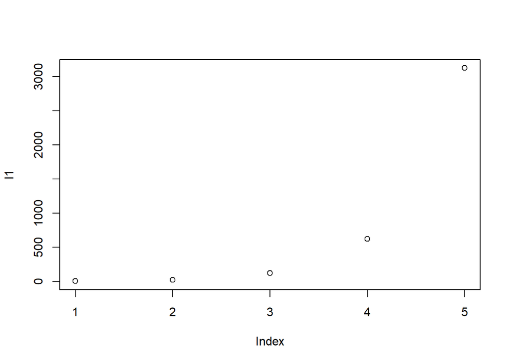

```r
plot(l1)
```

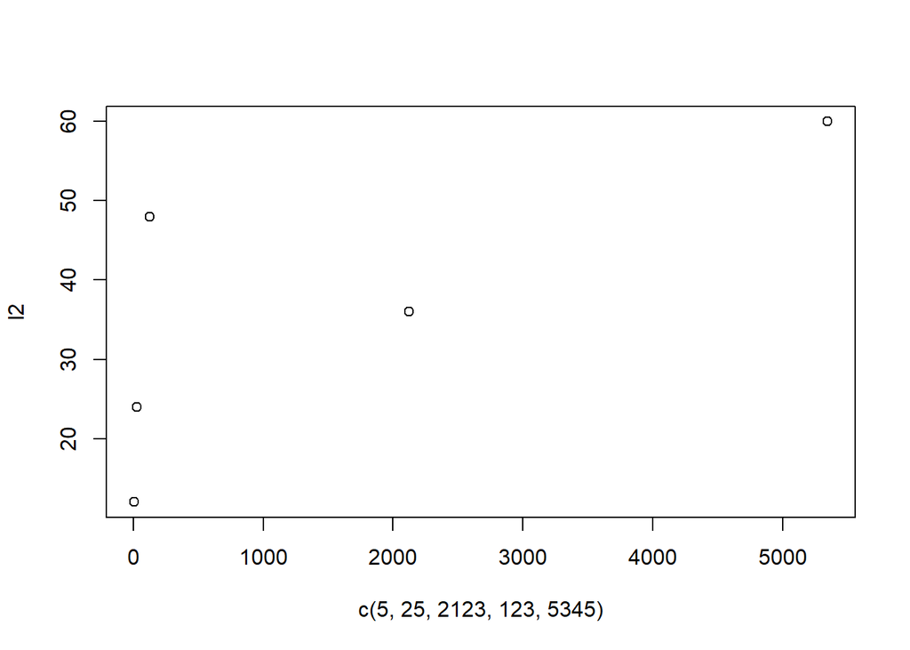

```r
plot(c(5,25,2123,123,5345),l2)
```

In R können auch ganz einfach eigene Funktionen geschrieben werden. Hilfe gibt es hier: https://www.datacamp.com/community/tutorials/functions-in-r-a-tutorial Zu allen Funktionen gibt es eine Hilfe, welche die möglichen Optionen (`arguments`) und die grundsätzliche Funktionsweise der Funktion beschreibt. ACHTUNG: Ohne Klammern hinter der Funktion, über die man Infos haben will.

```r
help(sd)
?sd
?summary
```

## Only numbers?

Bisher hatten wir nur Zahlen in unseren Beispielen. In R ist es aber auch möglich (und meistens unproblematisch) mit anderen Datentypen - wie bspw. Text oder Ja/Nein-Zuständen - zu arbeiten.

### Text

Inhalte mit Text wird meist in Anführungsstriche oder Hochkommata gesetzt. Die `Klasse` dieses Objekts ist dann automatisch `character`.

```r
txt <- "Das ist ein Text"
txt
```

```
## [1] "Das ist ein Text"
```

```r
class(txt)
```

```
## [1] "character"
```

### Boolean/Logical

Manchmal bietet es sich an nur “Wahr” oder “Falsch” als eigenen Datentypen zu nutzen. Die Schlüsselwörter hier sind `TRUE` und `FALSE`. Immer das ganze Wort großgeschrieben. Oftmals wird diese Klasse dafür genutzt, Zustände abzufragen, bspw. ob etwas größer ist, ob der Inhalt übereinstimmt etc:

```r
WAHRODERFALSCH <- FALSE
class(WAHRODERFALSCH)
```

```
## [1] "logical"
```

```r
isTRUE(WAHRODERFALSCH)
```

```
## [1] FALSE
```

```r
3 > 5
```

```
## [1] FALSE
```

```r
ist3groesser5 <- 3 > 5
"Ist das ein Text" == txt
```

```
## [1] FALSE
```

### Integer und Float-Variablen

Zurück zu Zahlen: Bei Zahlen in R gibt es Unterschiede, ob die Zahl eine “Ganzzahl” (`integer`) oder eine Zahl mit Nachkommastellen (`numeric`) ist. Normalerweise ist der Unterschied in R egal und man kann mit beiden Typen identisch arbeiten. Es kann aber Fälle geben, in denen man den Typ bewusst ändern muss.

```r
is.integer(3.541)
```

```
## [1] FALSE
```

```r
is.integer(3)
```

```
## [1] FALSE
```

```r
class(3)
```

```
## [1] "numeric"
```

```r
integer3 <- as.integer(3)
is.integer(integer3)
```

```
## [1] TRUE
```

```r
class(3.654)
```

```
## [1] "numeric"
```

### Factor

Bei der Arbeit mit Surveys kommen außerdem häufig noch `factors` vor. Faktoren werden verwendet, um kategorische Daten darzustellen. Faktoren können geordnet oder ungeordnet sein und sind eine wichtige Klasse für statistische Analysen und zum Plotten. Sie sind die klassische Darstellungsweise von ordinalen Datentypen.

Faktoren werden als Ganzzahlen gespeichert und diesen eindeutigen Ganzzahlen sind Beschriftungen zugeordnet. Während Faktoren wie Zeichenvektoren aussehen (und sich oft verhalten), sind sie tatsächlich in Wirklichkeit ganze Zahlen. Manchmal fährt das zu Problemen, wenn man sie wie *strings/character* behandelt.

```r
education <- factor(c("low", "high", "medium", "high", "low", "medium", "high"))
levels(education)
```

```
## [1] "high"   "low"    "medium"
```

```r
education
```

```
## [1] low    high   medium high   low    medium high
## Levels: high low medium
```

```r
education <- factor(education, levels = c("low", "medium", "high"))
levels(education)
```

```
## [1] "low"    "medium" "high"
```

```r
min(education) # doesn't work
```

```
## Error in Summary.factor(structure(c(1L, 3L, 2L, 3L, 1L, 2L, 3L), .Label = c("low", : 'min' not meaningful for factors
```

```r
education <- factor(education, levels = c("low", "medium", "high"), ordered = TRUE)
levels(education)
```

```
## [1] "low"    "medium" "high"
```

```r
min(education) # works!
```

```
## [1] low
## Levels: low < medium < high
```

### verschiedene Datentypen in einer Tabelle

Fügt man unterschiedliche Datentypen zusammen, so ist der Unterschied zwischen einer `matrix` und einem `data.frame` wichtig (siehe nächstes Kapitel). Während in einer matrix nur Elemente des gleichen Datentyps vorhanden sein können, sind bei einem data.frame auch unterschiedliche erlaubt.

```r
numbers <- c(1,2,31,43,5,16)
txt <- c("a","b","oma","uni","zwei Wörter","z")
logical <- c(FALSE,TRUE,FALSE,FALSE,TRUE,FALSE)
factors <- factor(c("low", "high", "medium", "high", "low", "medium"))

tabelle <- cbind(numbers,txt,logical,factors)
## zum verbinden von Spalten (column-bind); zum verbinden von Zeilen rbind() (row-bind)
tabelle #Man sieht, alle Datentypen wurden zu "Texten" gemacht. Anführungsstriche sind um die Werte herum.
```

```
##      numbers txt           logical factors
## [1,] "1"     "a"           "FALSE" "2"
## [2,] "2"     "b"           "TRUE"  "1"
## [3,] "31"    "oma"         "FALSE" "3"
## [4,] "43"    "uni"         "FALSE" "1"
## [5,] "5"     "zwei Wörter" "TRUE"  "2"
## [6,] "16"    "z"           "FALSE" "3"
```

```r
class(tabelle) # R hat die Tabelle automatisch zur Matrix gemacht und deshalb alle Datentypen "gleich" gemacht.
```

```
## [1] "matrix"
```

```r
tabelle2 <- data.frame(numbers,txt,logical,factors, stringsAsFactors = FALSE)
tabelle2
```

```
##   numbers         txt logical factors
## 1       1           a   FALSE     low
## 2       2           b    TRUE    high
## 3      31         oma   FALSE  medium
## 4      43         uni   FALSE    high
## 5       5 zwei Wörter    TRUE     low
## 6      16           z   FALSE  medium
```

```r
class(tabelle2)
```

```
## [1] "data.frame"
```

```r
class(tabelle2$txt)
```

```
## [1] "character"
```

```r
class(tabelle2$numbers)
```

```
## [1] "numeric"
```

## Data Frames

Normalerweise haben wir als Datenwissenschaftler aber selten einzelne Rechnungen oder Vektoren, sondern Tabellen mit Zeilen als Beobachtungen und Spalten als Variablen. Diese werden in R als `Data Frames` dargestellt (oder als Matrix, aber mit dataframes ist es meistens einfacher zu arbeiten).

```r
data.frame(l1,l2)
```

```
##     l1 l2
## 1    5 12
## 2   25 24
## 3  125 36
## 4  625 48
## 5 3125 60
```

```r
df <- data.frame(l1,l2)
df
```

```
##     l1 l2
## 1    5 12
## 2   25 24
## 3  125 36
## 4  625 48
## 5 3125 60
```

Einzelne Elemente des `df` lassen sich über eckige Klammern hinter dem Objektnamen auswählen. Dabei ist die erste Zahl die Nummer der Zeile und die zweite Zahl die Nummer der Spalte. Durch weglassen einer Zahl, wird entweder die ganze Zeile oder die ganze Spalte ausgegeben.

```r
df[3,2]
```

```
## [1] 36
```

```r
df[ ,2]
```

```
## [1] 12 24 36 48 60
```

```r
df[3, ]
```

```
##    l1 l2
## 3 125 36
```

```r
df[4,5]
```

[output not shown]

Variablen (Spalten) lassen sich auch durch den Namen anwählen, indem hinter den Objektnamen ein `$` geschrieben wird. RStudio schlägt einem dann meist sogar eine Liste vor, aus der man auswählen kann. Wiederrum kann man durch eckige Klammern, einzelne oder mehrere Elemente auswählen.

```r
summary(df)
```

```
##        l1             l2
##  Min.   :   5   Min.   :12
##  1st Qu.:  25   1st Qu.:24
##  Median : 125   Median :36
##  Mean   : 781   Mean   :36
##  3rd Qu.: 625   3rd Qu.:48
##  Max.   :3125   Max.   :60
```

```r
summary(df$l1)
```

```
##    Min. 1st Qu.  Median    Mean 3rd Qu.    Max.
##       5      25     125     781     625    3125
```

```r
df$l2
```

```
## [1] 12 24 36 48 60
```

```r
df$l1[3]
```

```
## [1] 125
```

```r
df$l2[4]
```

```
## [1] 48
```

```r
df$l1[1:3]
```

```
## [1]   5  25 125
```

```r
df$l1[1:2]
```

```
## [1]  5 25
```

```r
df$l1[-c(3,5)]
```

```
## [1]   5  25 625
```

Durch logische Operatoren lassen sich so bestimmte Zeilen suchen/ausschließen. So könnte man beispielsweise einen Datensatz mit mehreren Ländern so bearbeiten, dass am Ende nur ein Land heraus käme. Oder nur Menschen über 55 Jahre im Datensatz enthalten sind etc.

```r
df
```

```
##     l1 l2
## 1    5 12
## 2   25 24
## 3  125 36
## 4  625 48
## 5 3125 60
```

```r
df[df$l1>100, ]
```

```
##     l1 l2
## 3  125 36
## 4  625 48
## 5 3125 60
```

*Gesprochen: Der Datensatz df und alle Spalten (Hinter dem Komma ist leer). Aber nur die Zeilen, wo in Spalte 1 (l1) Werte über 100 stehen.*

## Daten einlesen

Die einfachste Art Daten einzulesen ist, wenn sie als einfach “Text-Datei” vorliegen. Beispielsweise .CSV (comma-separated-values), oder anderweitige Formate mit einem eindeutigen Symbol als Trennzeichen für Spalten.

Aber auch andere Formate lassen sich in R einlesen, nur braucht man hierzu meistens zusätzliche Pakete und Funktionen.

### Aus csv-Dateien

Im amerikanischen Raum wird die csv-Datei mit Kommata als Spaltentrennzeichen und dem Punkt als Dezimalzeichen bei Zahlen verwendet. Im europäischen Raum wird meistens das Semikolon als Spaltentrennzeichen und das Komma als Dezimalzeichen genutzt. In R wurden deshalb 2 Arten von CSV-Einlese-Funktionen implementiert. read.csv für den amerikanischen Raum und read.csv2 für den europäischen. Die Funktionen lassen sich aber über die Optionen (`arguments`) anpassen.

```r
read.csv(file = "../data/datensatz_grades.csv", sep = ";", dec = ",")
```

```
##    id     name semester Note.P1 Note.P2 Note.P3 gesamt
## 1   1      Mia        3     2.3     2.0     2.7    2.4
## 2   2     Emma        5     2.3     1.3     2.0    2.0
## 3   3    Sofia        9     1.7     1.7     1.7    1.7
## 4   4   Hannah        3     1.7     5.0     1.3    1.8
## 5   5   Emilia       11     2.3     2.3     2.3    2.3
## 6   6     Anna        9     1.3     1.0     1.3    1.2
## 7   7    Marie        9     2.3     1.0     1.7    1.8
## 8   8     Mila        7     1.7     1.0     1.7    1.6
## 9   9     Lina        3     3.3     2.7     5.0    4.0
## 10 10      Lea        9     1.0     2.0     1.3    1.2
## 11 11     Lena        5     1.3     2.3     1.7    1.6
## 12 12   Leonie        3     3.0     1.3     1.7    2.1
## 13 13   Amelie        3     1.7     1.7     1.3    1.5
## 14 14    Luisa        7     2.0     1.0     2.0    1.9
## 15 15 Giuliana       11     1.7     1.0     1.3    1.4
## 16 16   Gloria       11     1.7     2.0     2.3    2.0
## 17 17     Ines       11     2.3     1.0     1.7    1.8
## 18 18      Joy       11     2.7     2.0     3.0    2.7
## 19 19  Youssef        9     2.3     2.3     3.0    2.6
## 20 20  Domenik        9     2.0     5.0     2.3    2.4
## 21 21  Etienne        7     2.7     2.3     1.7    2.1
## 22 22    Jarno        5     2.3     1.7     1.7    1.9
## 23 23   Marian        3     1.7     1.3     1.7    1.6
## 24 24    Mason       11     2.0     1.3     1.7    1.7
## 25 25   Ragnar        7     2.3     1.7     2.0    2.0
## 26 26    Rayan        3     1.7     2.0     5.0    3.3
## 27 27    Semih        7     2.3     2.0     2.0    2.1
```

```r
read.csv2(file = "../data/datensatz_grades.csv")
```

```
##    id     name semester Note.P1 Note.P2 Note.P3 gesamt
## 1   1      Mia        3     2.3     2.0     2.7    2.4
## 2   2     Emma        5     2.3     1.3     2.0    2.0
## 3   3    Sofia        9     1.7     1.7     1.7    1.7
## 4   4   Hannah        3     1.7     5.0     1.3    1.8
## 5   5   Emilia       11     2.3     2.3     2.3    2.3
## 6   6     Anna        9     1.3     1.0     1.3    1.2
## 7   7    Marie        9     2.3     1.0     1.7    1.8
## 8   8     Mila        7     1.7     1.0     1.7    1.6
## 9   9     Lina        3     3.3     2.7     5.0    4.0
## 10 10      Lea        9     1.0     2.0     1.3    1.2
## 11 11     Lena        5     1.3     2.3     1.7    1.6
## 12 12   Leonie        3     3.0     1.3     1.7    2.1
## 13 13   Amelie        3     1.7     1.7     1.3    1.5
## 14 14    Luisa        7     2.0     1.0     2.0    1.9
## 15 15 Giuliana       11     1.7     1.0     1.3    1.4
## 16 16   Gloria       11     1.7     2.0     2.3    2.0
## 17 17     Ines       11     2.3     1.0     1.7    1.8
## 18 18      Joy       11     2.7     2.0     3.0    2.7
## 19 19  Youssef        9     2.3     2.3     3.0    2.6
## 20 20  Domenik        9     2.0     5.0     2.3    2.4
## 21 21  Etienne        7     2.7     2.3     1.7    2.1
## 22 22    Jarno        5     2.3     1.7     1.7    1.9
## 23 23   Marian        3     1.7     1.3     1.7    1.6
## 24 24    Mason       11     2.0     1.3     1.7    1.7
## 25 25   Ragnar        7     2.3     1.7     2.0    2.0
## 26 26    Rayan        3     1.7     2.0     5.0    3.3
## 27 27    Semih        7     2.3     2.0     2.0    2.1
```

```r
daten <- read.csv2(file = "../data/datensatz_grades.csv")
```

### Dateien aus Stata oder SPSS

Daten von anderen statistischen Sprachen lassen sich meist mit dem Paket `foreign` einlesen und auch in diesen Formaten abspeichern.

```r
#install.packages(c("openxlsx","foreign"))
library(foreign)

read.spss("../data/datensatz_grades.sav")
```

```
## re-encoding from UTF-8
```

```
## $id
##  [1]  1  2  3  4  5  6  7  8  9 10 11 12 13 14 15 16 17 18 19 20 21 22 23
## [24] 24 25 26 27
##
## $name
##  [1] "Mia     " "Emma    " "Sofia   " "Hannah  " "Emilia  " "Anna    "
##  [7] "Marie   " "Mila    " "Lina    " "Lea     " "Lena    " "Leonie  "
## [13] "Amelie  " "Luisa   " "Giuliana" "Gloria  " "Ines    " "Joy     "
## [19] "Youssef " "Domenik " "Etienne " "Jarno   " "Marian  " "Mason   "
## [25] "Ragnar  " "Rayan   " "Semih   "
##
## $semester
##  [1]  3  5  9  3 11  9  9  7  3  9  5  3  3  7 11 11 11 11  9  9  7  5  3
## [24] 11  7  3  7
##
## $NoteP1
##  [1] 2.3 2.3 1.7 1.7 2.3 1.3 2.3 1.7 3.3 1.0 1.3 3.0 1.7 2.0 1.7 1.7 2.3
## [18] 2.7 2.3 2.0 2.7 2.3 1.7 2.0 2.3 1.7 2.3
##
## $NoteP2
##  [1] 2.0 1.3 1.7 5.0 2.3 1.0 1.0 1.0 2.7 2.0 2.3 1.3 1.7 1.0 1.0 2.0 1.0
## [18] 2.0 2.3 5.0 2.3 1.7 1.3 1.3 1.7 2.0 2.0
##
## $NoteP3
##  [1] 2.7 2.0 1.7 1.3 2.3 1.3 1.7 1.7 5.0 1.3 1.7 1.7 1.3 2.0 1.3 2.3 1.7
## [18] 3.0 3.0 2.3 1.7 1.7 1.7 1.7 2.0 5.0 2.0
##
## $gesamt
##  [1] 2.4 2.0 1.7 1.8 2.3 1.2 1.8 1.6 4.0 1.2 1.6 2.1 1.5 1.9 1.4 2.0 1.8
## [18] 2.7 2.6 2.4 2.1 1.9 1.6 1.7 2.0 3.3 2.1
##
## attr(,"label.table")
## attr(,"label.table")$id
## NULL
##
## attr(,"label.table")$name
## NULL
##
## attr(,"label.table")$semester
## NULL
##
## attr(,"label.table")$NoteP1
## NULL
##
## attr(,"label.table")$NoteP2
## NULL
##
## attr(,"label.table")$NoteP3
## NULL
##
## attr(,"label.table")$gesamt
## NULL
##
## attr(,"codepage")
## [1] 65001
## attr(,"variable.labels")
## named character(0)
```

```r
read.dta("../data/datensatz_grades.dta")
```

```
##    id     name semester Note_P1 Note_P2 Note_P3 gesamt
## 1   1      Mia        3     2.3     2.0     2.7    2.4
## 2   2     Emma        5     2.3     1.3     2.0    2.0
## 3   3    Sofia        9     1.7     1.7     1.7    1.7
## 4   4   Hannah        3     1.7      NA     1.3    1.8
## 5   5   Emilia       11     2.3     2.3     2.3    2.3
## 6   6     Anna        9     1.3     1.0     1.3    1.2
## 7   7    Marie        9     2.3     1.0     1.7    1.8
## 8   8     Mila        7     1.7     1.0     1.7    1.6
## 9   9     Lina        3     3.3     2.7     5.0    4.0
## 10 10      Lea        9     1.0     2.0     1.3    1.2
## 11 11     Lena        5     1.3     2.3     1.7    1.6
## 12 12   Leonie        3     3.0     1.3     1.7    2.1
## 13 13   Amelie        3     1.7     1.7     1.3    1.5
## 14 14    Luisa        7     2.0     1.0     2.0    1.9
## 15 15 Giuliana       11     1.7     1.0     1.3    1.4
## 16 16   Gloria       11     1.7     2.0     2.3    2.0
## 17 17     Ines       11     2.3     1.0     1.7    1.8
## 18 18      Joy       11     2.7     2.0     3.0    2.7
## 19 19  Youssef        9     2.3     2.3     3.0    2.6
## 20 20  Domenik        9     2.0      NA     2.3    2.4
## 21 21  Etienne        7     2.7     2.3     1.7    2.1
## 22 22    Jarno        5     2.3     1.7     1.7    1.9
## 23 23   Marian        3     1.7     1.3     1.7    1.6
## 24 24    Mason       11     2.0     1.3     1.7    1.7
## 25 25   Ragnar        7     2.3     1.7     2.0    2.0
## 26 26    Rayan        3     1.7     2.0     5.0    3.3
## 27 27    Semih        7     2.3     2.0     2.0    2.1
```

### Aus Excel-Dateien

Zun?chst einmal ist es möglich aus Excel heraus auch CSV-Dateien zu speichern. Arbeitet man also selber erst mit Excel und will seine Daten dann in R einlesen, ist es meistens einfacher, die Datei direkt als CSV zu speichern. Hat man aber eine xlsx-Datei so kann man diese mit den Paketen `xlsx` oder `openxlsx` einlesen.

```r
library(openxlsx)
grades <- read.xlsx('../data/datensatz_grades.xlsx', sheet = 1)
grades
```

```
##    id     name semester Note.P1 Note.P2 Note.P3 gesamt
## 1   1      Mia        3     2.3     2.0     2.7    2.4
## 2   2     Emma        5     2.3     1.3     2.0    2.0
## 3   3    Sofia        9     1.7     1.7     1.7    1.7
## 4   4   Hannah        3     1.7     5.0     1.3    1.8
## 5   5   Emilia       11     2.3     2.3     2.3    2.3
## 6   6     Anna        9     1.3     1.0     1.3    1.2
## 7   7    Marie        9     2.3     1.0     1.7    1.8
## 8   8     Mila        7     1.7     1.0     1.7    1.6
## 9   9     Lina        3     3.3     2.7     5.0    4.0
## 10 10      Lea        9     1.0     2.0     1.3    1.2
## 11 11     Lena        5     1.3     2.3     1.7    1.6
## 12 12   Leonie        3     3.0     1.3     1.7    2.1
## 13 13   Amelie        3     1.7     1.7     1.3    1.5
## 14 14    Luisa        7     2.0     1.0     2.0    1.9
## 15 15 Giuliana       11     1.7     1.0     1.3    1.4
## 16 16   Gloria       11     1.7     2.0     2.3    2.0
## 17 17     Ines       11     2.3     1.0     1.7    1.8
## 18 18      Joy       11     2.7     2.0     3.0    2.7
## 19 19  Youssef        9     2.3     2.3     3.0    2.6
## 20 20  Domenik        9     2.0     5.0     2.3    2.4
## 21 21  Etienne        7     2.7     2.3     1.7    2.1
## 22 22    Jarno        5     2.3     1.7     1.7    1.9
## 23 23   Marian        3     1.7     1.3     1.7    1.6
## 24 24    Mason       11     2.0     1.3     1.7    1.7
## 25 25   Ragnar        7     2.3     1.7     2.0    2.0
## 26 26    Rayan        3     1.7     2.0     5.0    3.3
## 27 27    Semih        7     2.3     2.0     2.0    2.1
```